# Air flight cancellation analysis

## by Valeriya Petrenko

```python
import numpy as np
import pandas as pd
import matplotlib.pyplot as plt
import seaborn as sns
import sys
from datetime import datetime
import geopandas as gpd

%matplotlib inline

from IPython.core.display import display, HTML
display(HTML("<style>.container { width:100% !important; }</style>"))
pd.set_option('display.max_columns', 500)
pd.set_option('display.width', 1000)
pd.set_option('max_colwidth', 100)
import warnings
warnings.filterwarnings('ignore')
from utils import *
```

## Load datasets

```python
%%time
cancellation_fname = "./df_cancellation_1988-2018.pkl"
if not os.path.exists(cancellation_fname):
    print("First run data-preparation notebook")
else:
    df = pd.read_pickle(cancellation_fname)
```

```
CPU times: user 12 ms, sys: 24 ms, total: 36 ms
Wall time: 45.1 ms
```

```python
df.isnull().sum()
```

```
Year             0
Month            0
UniqueCarrier    0
Dest             0
Flights          0
Cancelled        0
dtype: int64
```

```python
df.shape
```

```
(414854, 6)
```

```python
memory_usage(df)
```

```
'Memory usage: 22.2 Mb'
```

- get all unique carriers

```python
carriers = df.UniqueCarrier.unique()
carriers
```

```
array(['AA', 'AS', 'CO', 'DL', 'EA', 'HP', 'NW', 'PA (1)', 'PI', 'PS',
       'TW', 'UA', 'US', 'WN', 'ML (1)', 'AQ', 'MQ', 'B6', 'DH', 'EV',
       'FL', 'OO', 'TZ', 'XE', 'HA', 'OH', 'RU', 'F9', 'YV', '9E', 'VX',
       'NK', 'YX', 'G4'], dtype=object)
```

```python
# get carrier data
df_carrier = pd.read_csv("./carriers.csv")
df_carrier.sample(4)
```

|  | Code | Description |
| --- | --- | --- |
| 1355 | W9 | Eastwind Airlines Inc. |
| 756 | L2 | Lynden Air Cargo Airlines |
| 335 | CAZ | CAT Aviation |
| 477 | EFA | Executive Four Winds |

- verify if all carriers we have in dataset are present in carriers.csv

```python
carriers_desc = df_carrier.Code
set(carriers).difference(set(carriers).intersection(carriers_desc))
```

```
{'RU'}
```

- lets' concentrate only on large airline whose total number of flights exceeds 1 million

```python
min_flights_total = 1e6
```

```python
df_c = df.groupby(['UniqueCarrier']).sum().sort_values(['Flights'])[['Flights', 'Cancelled']].reset_index()
df_c.head()
```

|  | UniqueCarrier | Flights | Cancelled |
| --- | --- | --- | --- |
| 0 | PS | 41911 | 272.0 |
| 1 | ML (1) | 70622 | 1342.0 |
| 2 | G4 | 96221 | 769.0 |
| 3 | AQ | 154381 | 2837.0 |
| 4 | TZ | 208420 | 2307.0 |

```python
grey = sns.color_palette()[7]
blue = sns.color_palette()[0]
palette = df_c.Flights.apply(lambda x: x > min_flights_total and blue or grey).values
```

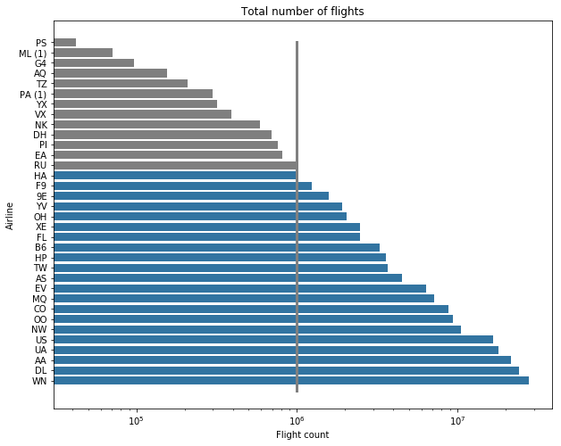

```python
#df_c["Cancelled %"] = df_c['Cancelled']/ df_c['Flights']*100
f, ax = plt.subplots(figsize=(10, 8))
plot = sns.barplot(y=df_c.UniqueCarrier, x=df_c.Flights, palette=palette)
plt.plot([min_flights_total, min_flights_total], [0, len(carriers)], linewidth=3, color="grey")
plt.title("Total number of flights");
ax.set(xscale="log")
plt.ylabel("Airline");
plt.xlabel("Flight count");
```

```python
df_temp = df_c[df_c.Flights > min_flights_total][['UniqueCarrier']]
df_carrier_large = df_carrier.merge(df_temp, how="inner", right_on="UniqueCarrier", left_on="Code")\
                             .drop('Code', axis=1)\
                             .set_index(['UniqueCarrier'])
df_carrier_large
```

| UniqueCarrier | Description |
| --- | --- |
| 9E | Pinnacle Airlines Inc. |
| AA | American Airlines Inc. |
| AS | Alaska Airlines Inc. |
| B6 | JetBlue Airways |
| CO | Continental Air Lines Inc. |
| DL | Delta Air Lines Inc. |
| EV | Atlantic Southeast Airlines |
| F9 | Frontier Airlines Inc. |
| FL | AirTran Airways Corporation |
| HA | Hawaiian Airlines Inc. |
| HP | America West Airlines Inc. (Merged with US Airways 9/05. Stopped reporting 10/07.) |
| MQ | American Eagle Airlines Inc. |
| NW | Northwest Airlines Inc. |
| OH | Comair Inc. |
| OO | Skywest Airlines Inc. |
| TW | Trans World Airways LLC |
| UA | United Air Lines Inc. |
| US | US Airways Inc. (Merged with America West 9/05. Reporting for both starting 10/07.) |
| WN | Southwest Airlines Co. |
| XE | Expressjet Airlines Inc. |
| YV | Mesa Airlines Inc. |

> since America West Airlines are merged with US Airways, let's not consider it

```python
df_carrier_large.loc['US'] = "US Airways Inc."
df_carrier_large = df_carrier_large.drop('HP').reset_index()
df_carrier_large
```

|  | UniqueCarrier | Description |
| --- | --- | --- |
| 0 | 9E | Pinnacle Airlines Inc. |
| 1 | AA | American Airlines Inc. |
| 2 | AS | Alaska Airlines Inc. |
| 3 | B6 | JetBlue Airways |
| 4 | CO | Continental Air Lines Inc. |
| 5 | DL | Delta Air Lines Inc. |
| 6 | EV | Atlantic Southeast Airlines |
| 7 | F9 | Frontier Airlines Inc. |
| 8 | FL | AirTran Airways Corporation |
| 9 | HA | Hawaiian Airlines Inc. |
| 10 | MQ | American Eagle Airlines Inc. |
| 11 | NW | Northwest Airlines Inc. |
| 12 | OH | Comair Inc. |
| 13 | OO | Skywest Airlines Inc. |
| 14 | TW | Trans World Airways LLC |
| 15 | UA | United Air Lines Inc. |
| 16 | US | US Airways Inc. |
| 17 | WN | Southwest Airlines Co. |
| 18 | XE | Expressjet Airlines Inc. |
| 19 | YV | Mesa Airlines Inc. |

```python
# add carrier description to original dataframe
df = df.merge(df_carrier_large, how="inner", on="UniqueCarrier")
df.isnull().sum()
```

```
Year             0
Month            0
UniqueCarrier    0
Dest             0
Flights          0
Cancelled        0
Description      0
dtype: int64
```

```python
df.UniqueCarrier.value_counts()
```

```
DL    44881
UA    34813
AA    34668
OO    29392
US    29056
NW    28096
EV    25501
MQ    22461
CO    22339
WN    21985
AS    16307
TW    12346
YV    10607
B6     9177
OH     8811
XE     8592
F9     8348
9E     8278
FL     7143
HA     2837
Name: UniqueCarrier, dtype: int64
```

```python
df.sample(4)
```

|  | Year | Month | UniqueCarrier | Dest | Flights | Cancelled | Description |
| --- | --- | --- | --- | --- | --- | --- | --- |
| 101696 | 2008 | 3 | DL | SAT | 141 | 3.0 | Delta Air Lines Inc. |
| 216540 | 2008 | 12 | US | HNL | 46 | 0.0 | US Airways Inc. |
| 96186 | 2003 | 8 | DL | STL | 179 | 0.0 | Delta Air Lines Inc. |
| 199236 | 1992 | 3 | US | LEX | 119 | 0.0 | US Airways Inc. |

- add airport data to the original dataframe

```python
# get airport data
df_airport = pd.read_csv("./data/data/airports.csv")
df_airport.sample(4)
```

|  | iata | airport | city | state | country | lat | long |
| --- | --- | --- | --- | --- | --- | --- | --- |
| 2280 | MLU | Monroe Regional | Monroe | LA | USA | 32.510866 | -92.037688 |
| 3277 | W78 | William M Tuck | South Boston | VA | USA | 36.710045 | -78.848020 |
| 242 | 2D1 | Barber | Alliance | OH | USA | 40.970891 | -81.099819 |
| 2229 | MEV | Minden-Tahoe | Minden | NV | USA | 39.000309 | -119.750806 |

```python
df.shape
```

```
(385638, 7)
```

```python
df = df.merge(df_airport, how="inner", left_on="Dest", right_on="iata").drop('iata', axis=1)
df.sample(4)
```

|  | Year | Month | UniqueCarrier | Dest | Flights | Cancelled | Description | airport | city | state | country | lat | long |
| --- | --- | --- | --- | --- | --- | --- | --- | --- | --- | --- | --- | --- | --- |
| 44205 | 1996 | 4 | US | CLE | 516 | 7.0 | US Airways Inc. | Cleveland-Hopkins Intl | Cleveland | OH | USA | 41.410894 | -81.849397 |
| 200932 | 2014 | 9 | DL | PHX | 528 | 0.0 | Delta Air Lines Inc. | Phoenix Sky Harbor International | Phoenix | AZ | USA | 33.434167 | -112.008056 |
| 306682 | 1998 | 6 | CO | ACK | 2 | 0.0 | Continental Air Lines Inc. | Nantucket Memorial | Nantucket | MA | USA | 41.253052 | -70.060181 |
| 140126 | 1990 | 6 | TW | LIT | 133 | 1.0 | Trans World Airways LLC | Adams | Little Rock | AR | USA | 34.729396 | -92.224246 |

```python
df.shape
```

```
(385136, 13)
```

```python
df[df.state=='GU'].head()
```

|  | Year | Month | UniqueCarrier | Dest | Flights | Cancelled | Description | airport | city | state | country | lat | long |
| --- | --- | --- | --- | --- | --- | --- | --- | --- | --- | --- | --- | --- | --- |
| 339413 | 1988 | 1 | CO | GUM | 147 | 5.0 | Continental Air Lines Inc. | Guam International | Agana | GU | USA | 13.48345 | -144.795983 |
| 339414 | 1988 | 2 | CO | GUM | 142 | 1.0 | Continental Air Lines Inc. | Guam International | Agana | GU | USA | 13.48345 | -144.795983 |
| 339415 | 1988 | 3 | CO | GUM | 151 | 0.0 | Continental Air Lines Inc. | Guam International | Agana | GU | USA | 13.48345 | -144.795983 |
| 339416 | 1988 | 4 | CO | GUM | 138 | 0.0 | Continental Air Lines Inc. | Guam International | Agana | GU | USA | 13.48345 | -144.795983 |
| 339417 | 1988 | 5 | CO | GUM | 144 | 1.0 | Continental Air Lines Inc. | Guam International | Agana | GU | USA | 13.48345 | -144.795983 |

> since we used inner merge, some of the airport were not found in the df_airport dataframe, but this number os smale so we'll ignore this fact

```python
df.set_index(['Year', 'Month', 'UniqueCarrier', 'Dest']).shape
```

```
(385136, 9)
```

### What is the structure of your dataset?

- i have 385136 entries in the dataset for flight cancellation
- each entry states the number of total flights and the number of cancelled flights each month for a given carrier and airport
- i augmented the data with the additional information about airport location, state and country, and a carrier full name

### What is/are the main feature(s) of interest in your dataset?

I'm interested to see the dynamics of the flight cancellations during last 30 years. Since some carriers have high volume of flights and some have lowe, i'm going to look only at the percentage of flights being cancelled.

### What features in the dataset do you think will help support your investigation into your feature(s) of interest?

I expect a spike of cancellations in 09/2001 (due to 9/11 tragic event). Also, i think some busy airports will constantly have higher rate of flight cancellation.

#### What is average percentage of the cancelled flights in 30 years

```python
cancelled = df.Cancelled.sum() / df.Flights.sum()
cancelled_p = cancelled * 100
print("Cancelled/total flights ratio over 30 years: {:.2} %".format(cancelled_p))
```

```
Cancelled/total flights ratio over 30 years: 1.8 %
```

## Univariate Exploration

```python
def percent_group_by_column(df, cols):
    res_cancel = df.groupby(cols)['Cancelled'].sum()
    res_total = df.groupby(cols)['Flights'].sum()
    # let's normalize data by dividing total number of cancellations by the total number of flights
    res_norm = res_cancel/res_total * 100
    res_norm.name = "Cancelled"
    res_norm = res_norm.reset_index()
    return res_total, res_norm
```

### Flight cancellations by year

```python
dft, dfy = percent_group_by_column(df, ["Year"])
dfy.head()
```

|  | Year | Cancelled |
| --- | --- | --- |
| 0 | 1988 | 0.917638 |
| 1 | 1989 | 1.187502 |
| 2 | 1990 | 1.018474 |
| 3 | 1991 | 0.828816 |
| 4 | 1992 | 1.059392 |

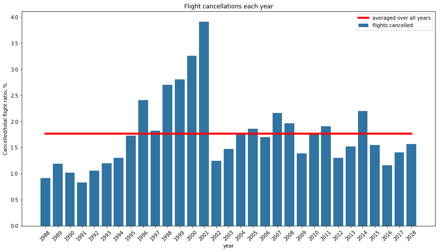

```python
years = dfy.Year
f, ax = plt.subplots(figsize=(15, 8), nrows=1)
base_color = sns.color_palette()[0]
plot = sns.barplot(y="Cancelled", x="Year", color=base_color, data=dfy,
                   label='flights cancelled')
plot.set_xticklabels(plot.get_xticklabels(), rotation=45);
plt.plot([0, len(years)-1], [cancelled_p, cancelled_p], linewidth=4, color="red",
         label='averaged over all years');
plt.title("Flight cancellations each year");
plt.legend();
plt.ylabel("Cancelled/total flight ratio, %");
plt.xlabel("year");
```

> starting from 1992, the relative number of cancelled flight has been increasing up until 2001 when it drastically dropped

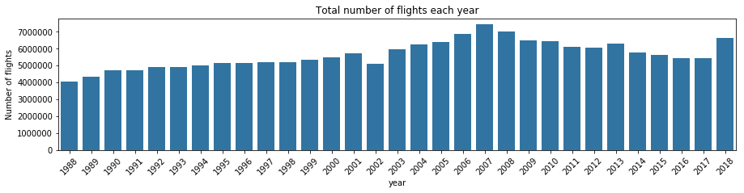

```python
f, ax = plt.subplots(figsize=(15, 3))
base_color = sns.color_palette()[0]
plot = sns.barplot(x=dft.index, y=dft, color=base_color,
                   label='flights cancelled')
plot.set_xticklabels(plot.get_xticklabels(), rotation=45);
plt.title("Total number of flights each year");
plt.ylabel("Number of flights");
plt.xlabel("year");
```

### Flight cancellation by month

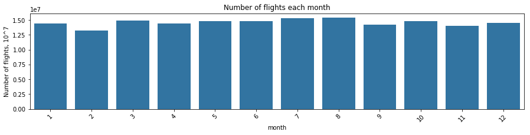

```python
dft, dfm = percent_group_by_column(df, ["Month"])
f, ax = plt.subplots(figsize=(15, 3))
base_color = sns.color_palette()[0]
plot = sns.barplot(x=dft.index, y=dft, color=base_color)
plot.set_xticklabels(plot.get_xticklabels(), rotation=45);
plt.title("Number of flights each month");
plt.ylabel("Number of flights, 10^7");
plt.xlabel("month");
```

> the number of flights is pretty uniform across each month

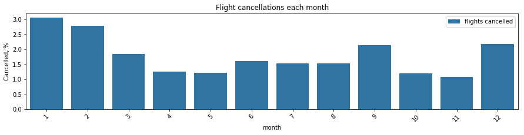

```python
f, ax = plt.subplots(figsize=(15, 3), nrows=1)
base_color = sns.color_palette()[0]
plot = sns.barplot(y="Cancelled", x="Month", color=base_color, data=dfm,
                   label='flights cancelled')
plot.set_xticklabels(plot.get_xticklabels(), rotation=45);
plt.title("Flight cancellations each month");
plt.legend();
plt.ylabel("Cancelled, %");
plt.xlabel("month");
```

> in winter months (December, January, February), and in September, there is a larger chance of a flight being cancelled

> the best months to travel are April, May, October, November

### Flight cancellation by carrier

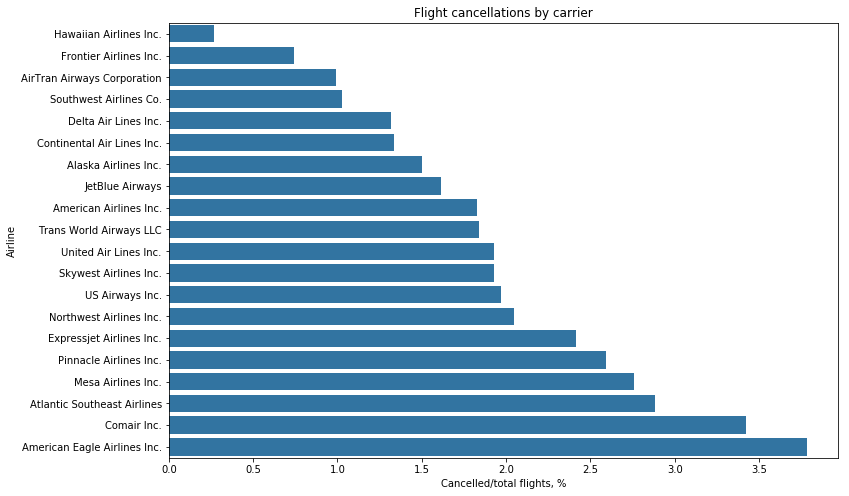

```python
dft, dfc = percent_group_by_column(df, ["Description"])
dfc = dfc.sort_values('Cancelled')
f, ax = plt.subplots(figsize=(12, 8), nrows=1)
base_color = sns.color_palette()[0]
plot = sns.barplot(x="Cancelled", y="Description", color=base_color, data=dfc)
plt.title("Flight cancellations by carrier");
plt.xlabel("Cancelled/total flights, %");
plt.ylabel("Airline");
```

### Flight cancellation by state

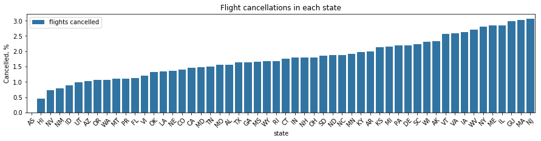

```python
dft, dfs = percent_group_by_column(df, ["state"])
dfs = dfs.sort_values('Cancelled')
f, ax = plt.subplots(figsize=(15, 3), nrows=1)
base_color = sns.color_palette()[0]
plot = sns.barplot(y="Cancelled", x="state", color=base_color, data=dfs,
                   label='flights cancelled')
plot.set_xticklabels(plot.get_xticklabels(), rotation=45);
plt.title("Flight cancellations in each state");
plt.legend();
plt.ylabel("Cancelled, %");
plt.xlabel("state");
```

```python
dfs.Cancelled.describe()
```

```
count    54.000000
mean      1.760356
std       0.690394
min       0.000000
25%       1.321842
50%       1.722022
75%       2.197797
max       3.070556
Name: Cancelled, dtype: float64
```

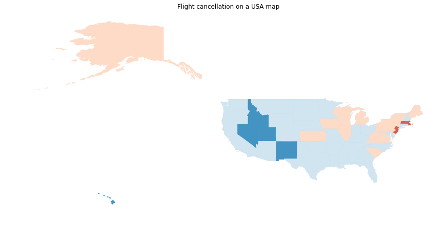

```python
def color_by_rate(x):
    colors = sns.color_palette("RdBu", n_colors=4)
    return colors[3 - int(x % 4)]
dfs['colors'] = dfs.Cancelled.apply(color_by_rate)

usa = gpd.read_file('states_21basic/states.shp')

def state_plotter(states, colors, us_map=True):
    fig, ax = plt.subplots(figsize=(15,20))
    plt.axis("off")
    plt.title("Flight cancellation on a USA map")
    usa_plot = usa
    if us_map:
        if 'HI' in states: # hawaii
            usa_plot = usa[:50]
        elif 'AK' in states: # alaska
            usa_plot = usa[1:51]
        elif 'AK' and 'HI' in states:
            usa_plot = usa[:51]
        else:
            usa_plot = usa[1:50]
        usa_plot.plot(ax=ax, alpha=0.3)

    for n, c in zip(states, colors):
        if n in usa.STATE_ABBR.values:
            usa[usa.STATE_ABBR == f'{n}'].plot(ax=ax, edgecolor=None, linewidth=2, color=c)
    # 0 < blue < 1
    # 1 < mint < 2
    # 2 < orange < 3
    # 3 < red < 4
    sns.palplot(sns.color_palette("RdBu", n_colors=4)[::-1])
    for i in range(4):
        x = i+1
        plt.text(-.3+i, 0, f"< {x} %")

state_plotter(dfs.state.values, dfs.colors.values)
```

> interestingly, the eastern states perform worse than the western states

> Hawaii, Nevada, New Mexico, Idaho, Utah and Arizona are among the states with least cancelled flights

> Massatusetts and New Jersey are the highest

## Bivariate Exploration

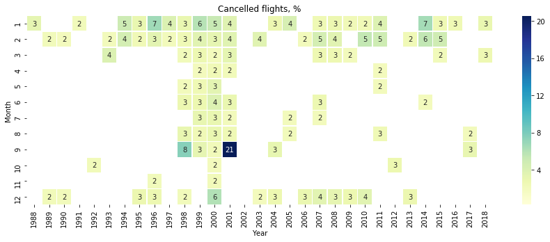

```python
dft, dfym = percent_group_by_column(df, cols=["Year", "Month"])
dfym_pivot = dfym.pivot(index="Month", columns="Year", values="Cancelled")
plt.figure(figsize=(15, 5))
mask = dfym_pivot < 2
ax = sns.heatmap(dfym_pivot, annot=True,  cmap='YlGnBu', fmt=".0f", linewidth=0.5, mask=mask)
plt.title("Cancelled flights, %");
plt.xlabel("Year");
plt.ylabel("Month");
```

- for clarity, the cancellations less than 2% are not shown
- 9/11 in 2001 clearly shows the greatest fraction of the cancelled flights that month
- apart from that flights in December-February period are more likely to be cancelled, which is consistent with our univariate analysis across months
- also, we can confirm that 1998-2001 was the worst period in the 30 years for flight cancellation
- let's look how stable are airline companies with time

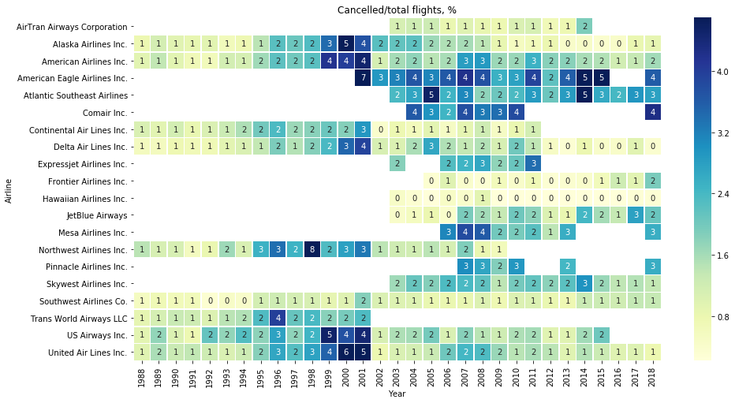

```python
dft, dfyc = percent_group_by_column(df, cols=["Year", "Description"])
dfyc_pivot = dfyc.pivot(columns="Year", index="Description", values="Cancelled")
plt.figure(figsize=(15, 8))
ax = sns.heatmap(dfyc_pivot, annot=True, cmap='YlGnBu', fmt=".0f", linewidth=0.5, robust=True)
plt.title("Cancelled/total flights, %");
plt.xlabel("Year");
plt.ylabel("Airline");
```

- many companies entered the market in 2003
- clearly, the best company to not to cancel its flights is Hawaiian Airlines
- the top 5 companies that contributed to the spike in flight cancellation between 1999-2001 are
  - American Airlines
  - Alaska Airlines
  - American Eagle Airlines
  - United Air Lines
  - US Airways
- discovered merges from this plot (with dates on merge from wikipedia):
  - AirTan Airways merged with Southwest Airlines in 2014
  - Comair merged with Delta in 2012 (for some reason we have a point in 2018 for Comair)
  - Continental merged with United Airlines in 2012
  - ExpressJet still exists, but we don't have data after 2011. The data looks like was mislabeled, since Atlantic Southeast was renamed to ExpressJet in 2011, so these two labels should be swapped. I'll keep using the original Atlantic SouthEast implying ExpressJet Airlines for simplicity
  - Northwest Airlines merged with Delta Air Lines in 2010
  - Pinnacle was acquired by Delta in 2013
  - Trans World Airways acquired by American Airlines in 2001
  - US Airways merged with American Airlines in 2015

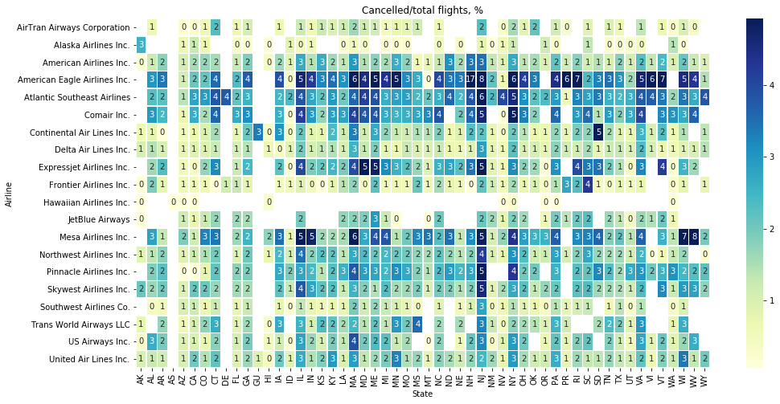

```python
dft, dfys = percent_group_by_column(df, cols=["Description", "state"])
dfys_pivot = dfys.pivot(columns="state", index="Description", values="Cancelled")
plt.figure(figsize=(16, 8))
ax = sns.heatmap(dfys_pivot, annot=True, cmap='YlGnBu', fmt=".0f", linewidth=0.5, robust=True)
plt.title("Cancelled/total flights, %");
plt.xlabel("State");
plt.ylabel("Airline");
```

> based on this heatmap we can't blame one specific state (and consequently, airport) for driving cancellation rate up for the airlines

> with the exception of MA, NY and NJ, it looks like airline itself is mostly responsible for flight cancellation. a good example is American Eagle Airlines which has consistently higher cancellations in each state compared to other airlines
- in further analysis, i'll exclude the airlines that don't exist anymore

```python
ceased_airlines = ['9E', 'CO', 'FL', 'NW', 'OH', 'TW', 'US', 'XE']
df_carrier_large_exist = df_carrier_large.set_index('UniqueCarrier').drop(ceased_airlines).reset_index()
```

```python
df_carrier_large_exist
```

|  | UniqueCarrier | Description |
| --- | --- | --- |
| 0 | AA | American Airlines Inc. |
| 1 | AS | Alaska Airlines Inc. |
| 2 | B6 | JetBlue Airways |
| 3 | DL | Delta Air Lines Inc. |
| 4 | EV | Atlantic Southeast Airlines |
| 5 | F9 | Frontier Airlines Inc. |
| 6 | HA | Hawaiian Airlines Inc. |
| 7 | MQ | American Eagle Airlines Inc. |
| 8 | OO | Skywest Airlines Inc. |
| 9 | UA | United Air Lines Inc. |
| 10 | WN | Southwest Airlines Co. |
| 11 | YV | Mesa Airlines Inc. |

```python
airlines_large_exist = df_carrier_large_exist.UniqueCarrier.values
airlines_large_exist
```

```
array(['AA', 'AS', 'B6', 'DL', 'EV', 'F9', 'HA', 'MQ', 'OO', 'UA', 'WN',
       'YV'], dtype=object)
```

## Multivariate Exploration

> Create plots of three or more variables to investigate your data even further. Make sure that your investigations are justified, and follow from your work in the previous sections.

```python
dft, dfdst = percent_group_by_column(df, cols=["Description", "state", "Month"])
```

```python
dfdst = dfdst.merge(df_carrier_large_exist, on="Description")
```

```python
dfdst.head()
```

|  | Description | state | Month | Cancelled | UniqueCarrier |
| --- | --- | --- | --- | --- | --- |
| 0 | Alaska Airlines Inc. | AK | 1 | 4.093211 | AS |
| 1 | Alaska Airlines Inc. | AK | 2 | 4.029079 | AS |
| 2 | Alaska Airlines Inc. | AK | 3 | 2.875090 | AS |
| 3 | Alaska Airlines Inc. | AK | 4 | 2.229989 | AS |
| 4 | Alaska Airlines Inc. | AK | 5 | 1.699513 | AS |

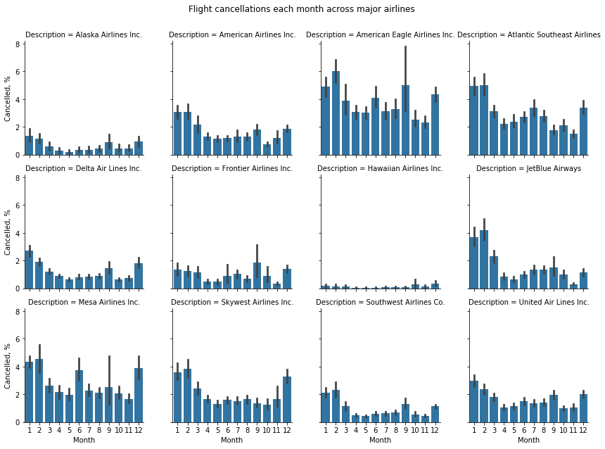

```python
g = sns.FacetGrid(data=dfdst, col='Description', col_wrap=4, size=3)
g.map(sns.barplot, 'Month', 'Cancelled');
g.set_xlabels('Month');
g.set_ylabels('Cancelled, %');
plt.subplots_adjust(top=0.9)
g.fig.suptitle("Flight cancellations each month across major airlines");
```

### Were there any interesting or surprising interactions between features?

> interestingly, for most airlines the other high month for flights to be cancelled is September